# Analysis on the empirical networks

Chang-Yu Chang

2022-06-14

# Introduction

- The R scripts (sourced in this Rmd) can be run externally to Rstudio.
- The R scripts are only for saving R functions, processing raw and temporary data.
- All visualization codes are in this Rmd file.

# 03A-make_network

- Make community network from `data/output/pairs.csv`.
- Plot networks and matrices

## Make network

```r
if (run_scripts) source("script/03A-make_network-01-make_pairwise_network.R")
```

Networks in matrix form

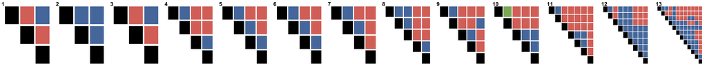

```r
p_list <- lapply(communities_network$Network, plot_adjacent_matrix)
plot_grid(plotlist = p_list, labels = 1:13, nrow = 1, scale = .9)
```

Networks in graph

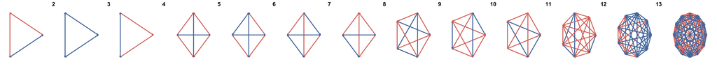

```r
p_list <- lapply(communities_network$Network, function(x) plot_competitive_network(x, node_size = 0))
plot_grid(plotlist = p_list, labels = 1:13, nrow = 1, hjust = 1)
```

## Randomize networks

```r
# It takes ~850 seconds = 15 mins to randomize 1000 times
if (run_scripts) source("script/03A-make_network-03-randomize_network.R")
```

C11R2 Left: observation Right: one randomized network

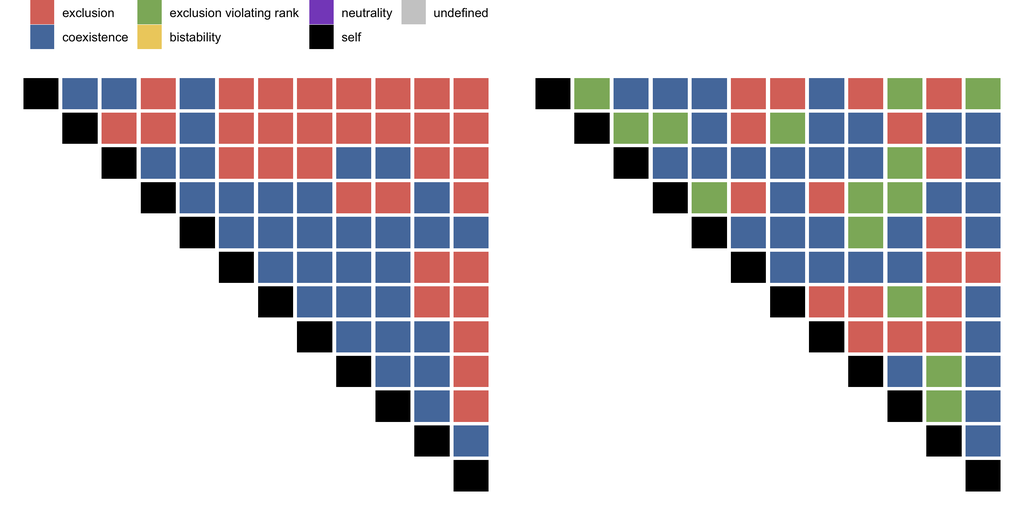

```r
load("~/Dropbox/lab/emergent-coexistence/data/output/communities_network_randomized.Rdata")
p1 <- communities_network_randomized %>%
    filter(Community == "C11R2") %>%
    pull(Network) %>% `[[`(1) %>%
    plot_adjacent_matrix(show.legend = T) +
    theme(legend.title = element_blank())
p2 <- communities_network_randomized$NetworkRandomized$C11R2[[1]] %>% plot_adjacent_matrix()
plot_grid(p1, p2, nrow = 1, axis = "tb", align = "h")
```

# 03B-network_measure

## Detect motifs in networks

```r
if (run_scripts) source("script/03B-network_measure-01-detect_motif.R")
```

- `communities_motif`: data.frame
- `networks_motif_randomized`: data.frame for all randomized networks motif counts

Empirical network motifs. 13 communities x 7 motifs = 91 rows

```r
read_csv("~/Dropbox/lab/emergent-coexistence/data/output/communities_motif.csv", col_types = cols())
```

| Community | Motif | Count | Fraction |
| --- | --- | --- | --- |
| C4R1 | 1 | 0 | 0.00000000 |
| C4R1 | 2 | 0 | 0.00000000 |
| C4R1 | 3 | 0 | 0.00000000 |
| C4R1 | 4 | 1 | 1.00000000 |
| C4R1 | 5 | 0 | 0.00000000 |
| C4R1 | 6 | 0 | 0.00000000 |
| C4R1 | 7 | 0 | 0.00000000 |
| C8R4 | 1 | 0 | 0.00000000 |
| C8R4 | 2 | 0 | 0.00000000 |
| C8R4 | 3 | 0 | 0.00000000 |

[output cut: 81 more lines]

Shuffled network motifs. 13 communities x 7 motifs x 1000 bootstraps = 91000 rows

```r
read_csv("~/Dropbox/lab/emergent-coexistence/data/output/communities_motif_randomized.csv", col_types = cols())
```

| Community | Replicate | Motif | Count | Fraction |
| --- | --- | --- | --- | --- |
| C4R1 | 1 | 1 | 0 | 0 |
| C4R1 | 1 | 2 | 0 | 0 |
| C4R1 | 1 | 3 | 1 | 1 |
| C4R1 | 1 | 4 | 0 | 0 |
| C4R1 | 1 | 5 | 0 | 0 |
| C4R1 | 1 | 6 | 0 | 0 |
| C4R1 | 1 | 7 | 0 | 0 |
| C4R1 | 2 | 1 | 0 | 0 |
| C4R1 | 2 | 2 | 0 | 0 |
| C4R1 | 2 | 3 | 0 | 0 |

[output cut: 990 more lines]